# Normalization performance report

- study: Illumina methylation data
- author: Analyst
- date: 28 July, 2016

## Parameters used to test normalization

```
## $variables
## [1] "Slide"         "sentrix_row"   "sentrix_col"   "bcd.plate"
## [5] "Sex"           "Creation_Date" "goyacase"
##
## $control.pcs
##  [1]  1  2  3  4  5  6  7  8  9 10
##
## $batch.pcs
##  [1]  1  2  3  4  5  6  7  8  9 10
##
## $batch.threshold
## [1] 1e-10
##
## $colours
## NULL
```

## Control probe scree plots

The variance captured by each principal component.

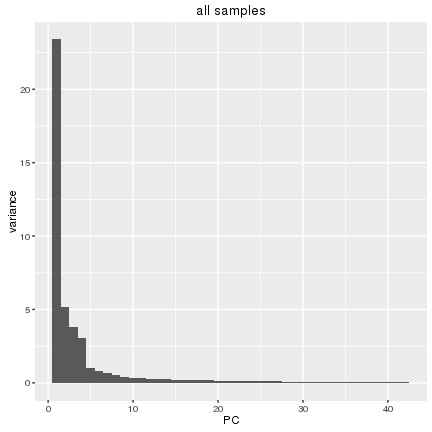

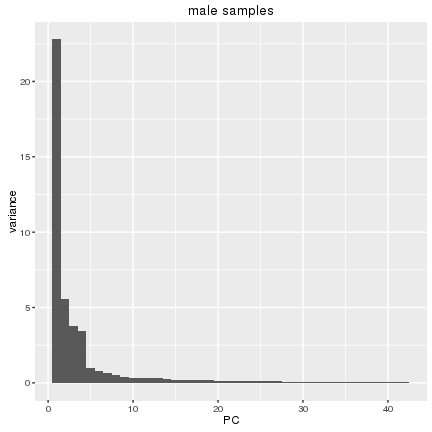

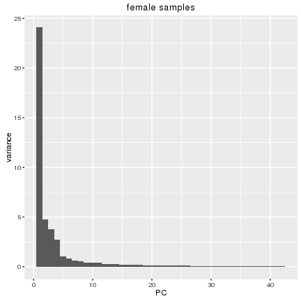

## Principal components of the control probes

The following plots show the first 3 principal components of the control matrix colored by batch variables. Batch variables with more than 10 levels are omitted.

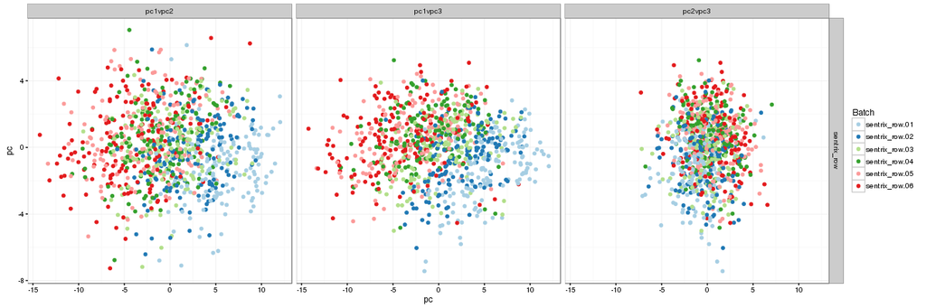

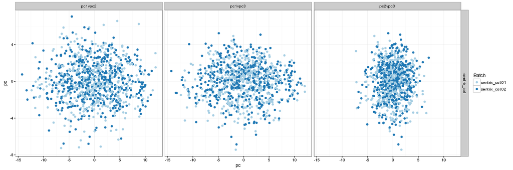

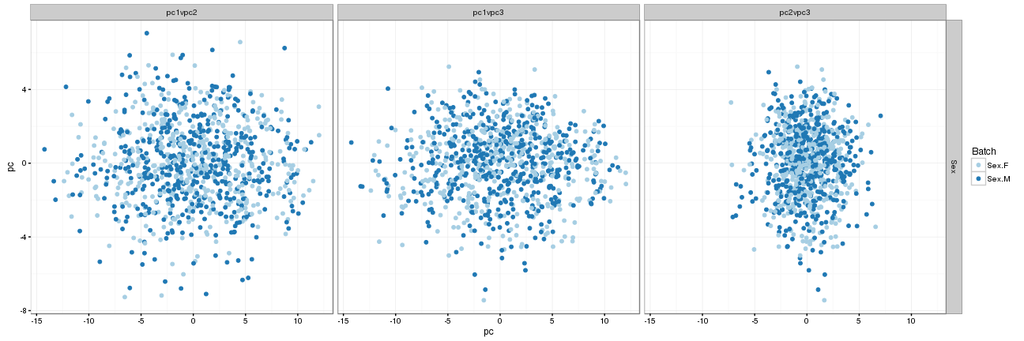

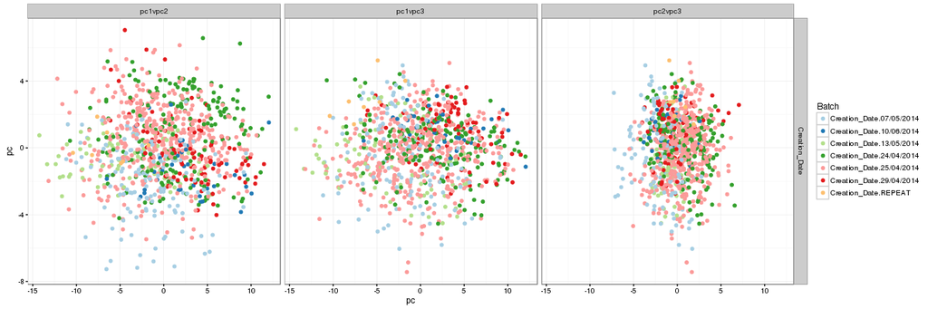

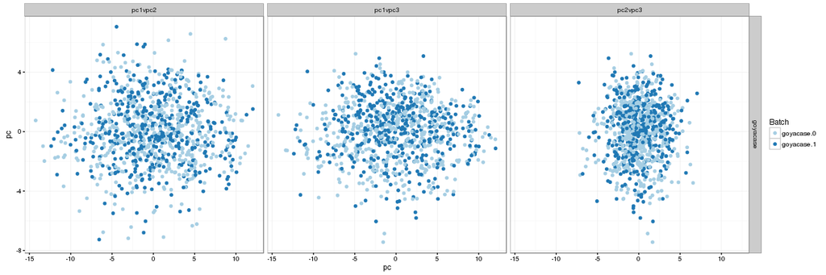

## Control probe associations with measured batch variables

Principal components of the control probes were regressed against batch variables. Shown are the \(-log_{10}\) p-values for these regressions. The horizontal dotted line denotes \(p = 0.05\) in log-scale.

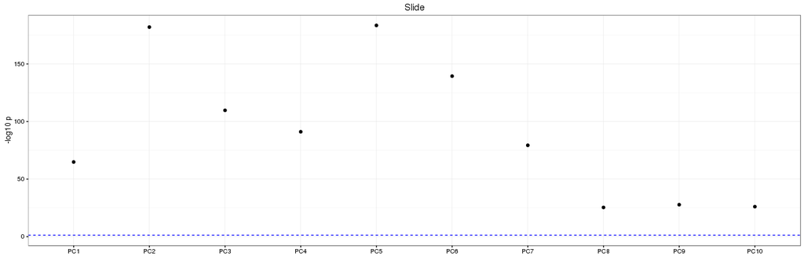

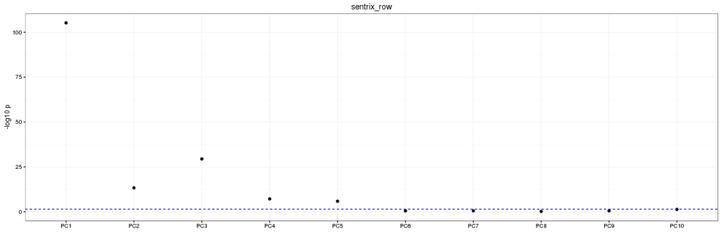

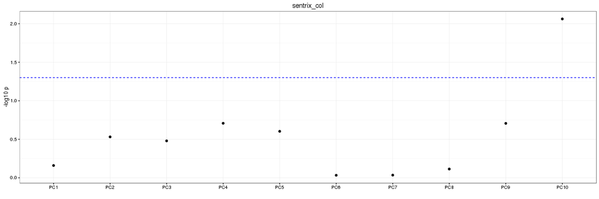

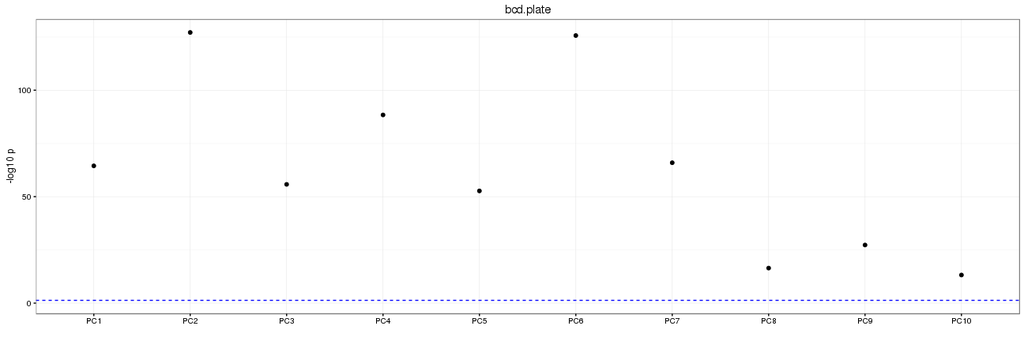

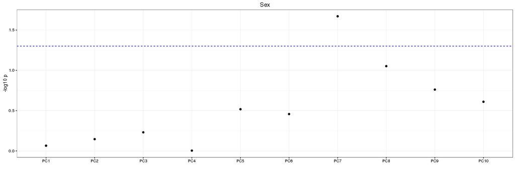

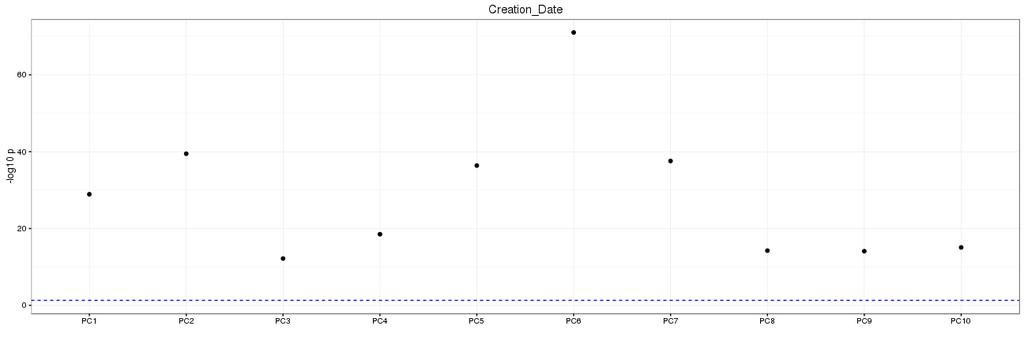

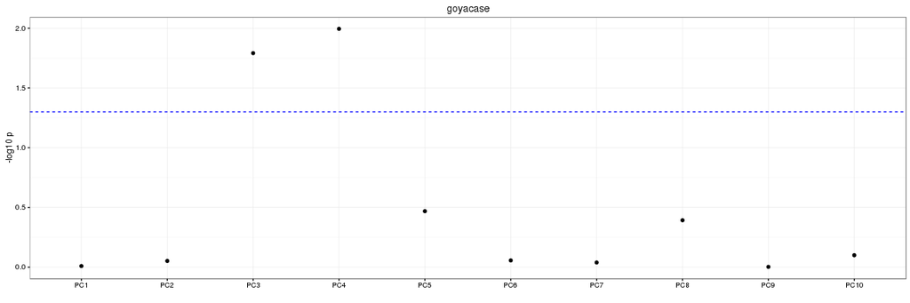

The following plots show regression coefficients when each principal component is regressed against each batch variable level along with 95% confidence intervals. Cases significantly different from zero are coloured red (p < 10<sup>-10</sup>, t-test).

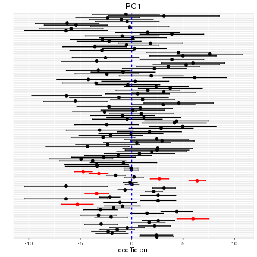

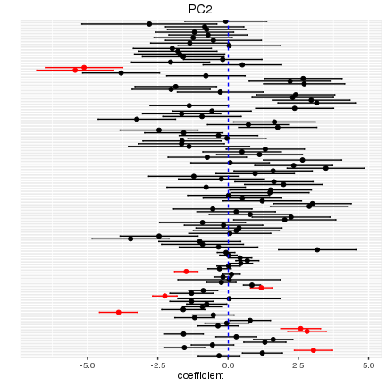

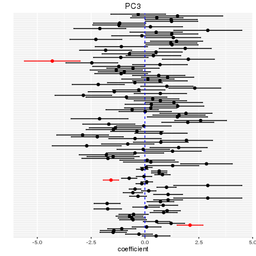

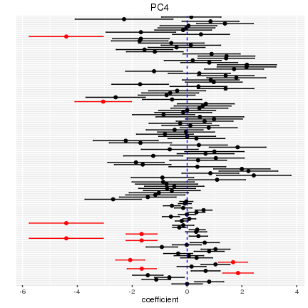

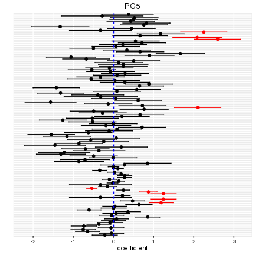

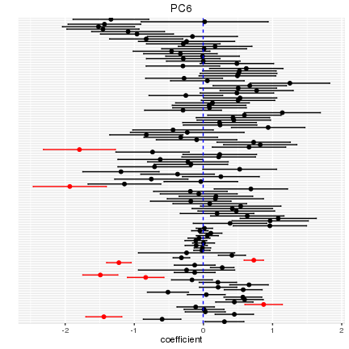

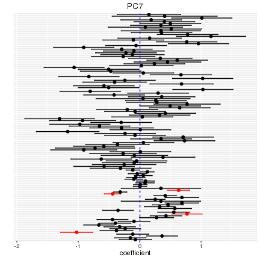

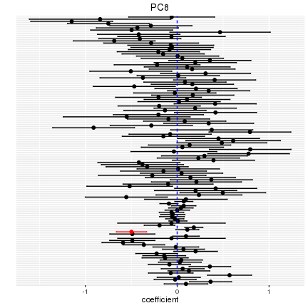

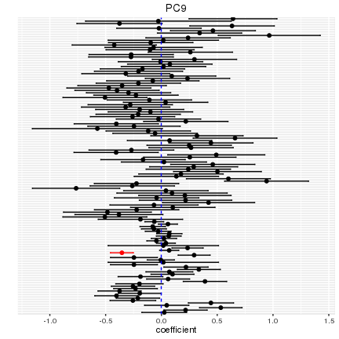

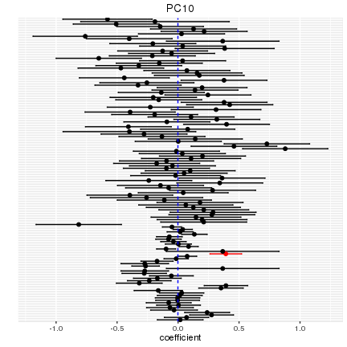

| batch.variable | batch.value | principal.component | test | p.value | estimate | lower | upper |
| --- | --- | --- | --- | --- | --- | --- | --- |
| Slide |  | PC1 | F-test | 1.39e-65 | 8.160 |  |  |
| sentrix_row |  | PC1 | F-test | 5.50e-106 | 131.569 |  |  |
| sentrix_row | 02 | PC1 | t-test | 3.66e-11 | 2.702 | 1.804 | 3.599 |
| sentrix_row | 01 | PC1 | t-test | 2.23e-59 | 6.383 | 5.569 | 7.197 |
| sentrix_row | 06 | PC1 | t-test | 2.12e-31 | -4.705 | -5.571 | -3.839 |
| sentrix_row | 05 | PC1 | t-test | 5.54e-15 | -3.195 | -4.089 | -2.300 |
| bcd.plate |  | PC1 | F-test | 3.43e-65 | 21.234 |  |  |
| bcd.plate | BCD169 | PC1 | t-test | 3.98e-17 | 5.978 | 4.420 | 7.537 |
| bcd.plate | BCD177 | PC1 | t-test | 6.58e-14 | -5.280 | -6.831 | -3.729 |
| Creation_Date |  | PC1 | F-test | 1.22e-29 | 26.840 |  |  |
| Creation_Date | 13/05/2014 | PC1 | t-test | 5.12e-11 | -3.388 | -4.526 | -2.250 |
| Slide |  | PC2 | F-test | 9.74e-183 | 25.625 |  |  |
| Slide | 9379086011 | PC2 | t-test | 2.47e-16 | -5.122 | -6.497 | -3.748 |
| Slide | 9379086009 | PC2 | t-test | 2.73e-18 | -5.438 | -6.806 | -4.071 |
| sentrix_row |  | PC2 | F-test | 4.66e-14 | 14.858 |  |  |
| sentrix_row | 01 | PC2 | t-test | 4.06e-15 | -1.490 | -1.905 | -1.074 |
| bcd.plate |  | PC2 | F-test | 7.63e-128 | 45.826 |  |  |
| bcd.plate | BCD161 | PC2 | t-test | 1.80e-22 | 3.040 | 2.361 | 3.719 |
| bcd.plate | BCD168 | PC2 | t-test | 4.42e-19 | 2.811 | 2.122 | 3.500 |
| bcd.plate | BCD169 | PC2 | t-test | 9.79e-16 | 2.586 | 1.878 | 3.293 |
| bcd.plate | BCD175 | PC2 | t-test | 1.33e-34 | -3.894 | -4.576 | -3.213 |
| Creation_Date |  | PC2 | F-test | 3.35e-40 | 36.779 |  |  |
| Creation_Date | 07/05/2014 | PC2 | t-test | 1.10e-28 | -2.249 | -2.685 | -1.813 |
| Creation_Date | 24/04/2014 | PC2 | t-test | 1.32e-11 | 1.182 | 0.799 | 1.566 |
| Slide |  | PC3 | F-test | 1.89e-110 | 13.687 |  |  |
| Slide | 9374342134 | PC3 | t-test | 2.26e-13 | -4.305 | -5.600 | -3.009 |
| sentrix_row |  | PC3 | F-test | 3.72e-30 | 31.953 |  |  |
| sentrix_row | 01 | PC3 | t-test | 8.67e-22 | -1.579 | -1.937 | -1.222 |
| bcd.plate |  | PC3 | F-test | 1.69e-56 | 18.350 |  |  |
| bcd.plate | BCD165 | PC3 | t-test | 1.78e-14 | 2.094 | 1.493 | 2.695 |

[output cut: 56 more lines]

## Principal components of the normalized betas

The following plots show the first 3 principal components of the most variable probes colored by batch variables. Batch variables with more than 10 levels are omitted.

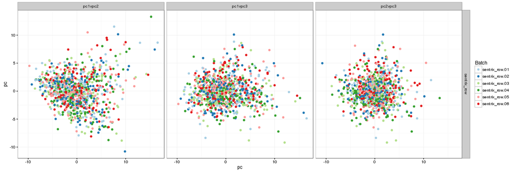

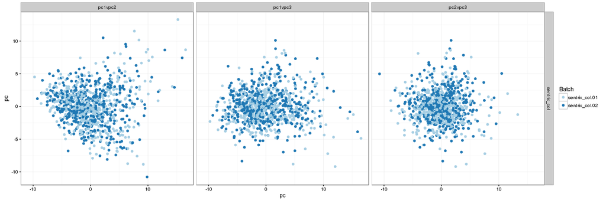

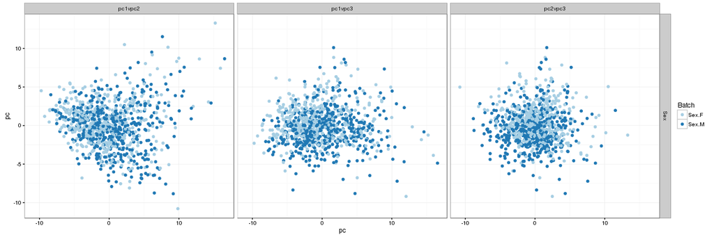

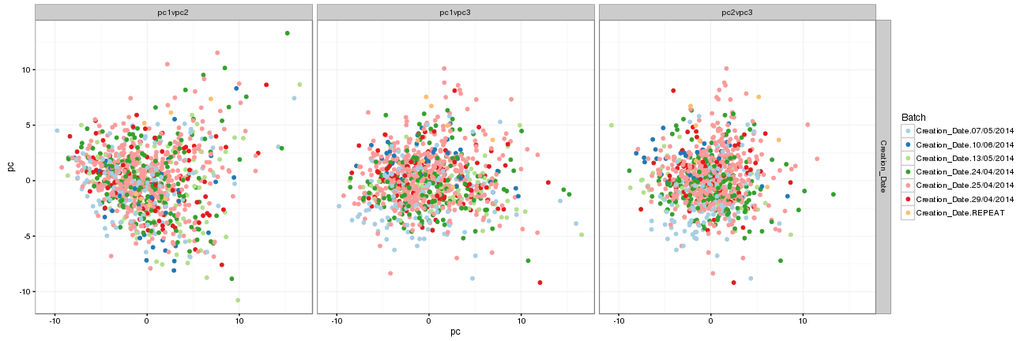

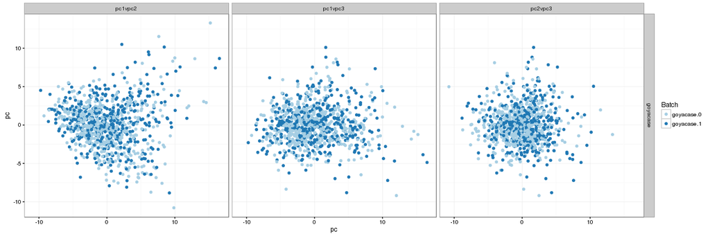